# Práctica del tema 2. Análisis de secuencias

28/01/2025

## Introducción

Antes de usar los datos de la práctica, deberías decirle a R en qué carpeta quieres trabajar, para que pueda encontrar la subcarpeta `data`, con los datos de la práctica. Por ejemplo, si has descargado y descomprimido la carpeta `T02_secuencias` en `/home/user/Downloads`, entonces ejecuta el comando siguiente **en la consola**:

```r
# "Set working directory":
setwd('/home/user/Downloads/T02_secuencias')
```

Imagina que en un laboratorio de biotecnología se aisla una cepa de levadura con capacidades metabólicas diferentes, y se decide secuenciarla para identificar en qué se diferencia genéticamente de la cepa de referencia.

## Genoma de referencia

El archivo `data/yeast.fasta` contiene las secuencias de sólo los tres primeros cromosomas del genoma de referencia de la levadura (para reducir el tamaño). Con los comandos siguientes, lo cargamos en la memoria de trabajo, mediante una función del paquete `Biostrings`.

```r
suppressMessages(library('Biostrings'))
genoma <- readDNAStringSet('data/yeast.fasta')
genoma
```

```
## DNAStringSet object of length 3:
##      width seq                                              names
## [1] 230218 CCACACCACACCCACACACCCAC...GTGTGGGTGTGGTGTGTGTGGG NC_001133.9 Sacch...
## [2] 813184 AAATAGCCCTCATGTACGTCTCC...TGGGTGTGGTGTGTGGGTGTGT NC_001134.8 Sacch...
## [3] 316620 CCCACACACCACACCCACACCAC...TGTGGTGGGTGTGGTGTGTGTG NC_001135.5 Sacch...
```

- ¿Qué clase de objeto es `genoma`?
- ¿De qué clase de objetos está compuesto?
- ¿Cómo extraerías la secuencia de uno de los cromosomas?
- ¿Cómo inspeccionarías la secuencia de un segmento concreto de un cromosoma?

## Anotaciones del genoma

El archivo `data/yeast.gtf.gz` contiene la anotación funcional de los tres primeros cromosomas de la levadura. Con los comandos siguientes, cargamos toda la información en un *marco de datos*.

```r
library(ape)
gtf <- read.gff('data/yeast.gtf.gz')
```

- ¿Cuántas columnas hay en el objeto `gtf`?
- ¿Cuáles son sus nombres?
- ¿Cuántos tipos diferentes de elementos funcionales hay?

Con el código siguiente representamos las posiciones de los genes de un cromosoma entre dos posiciones concretas.

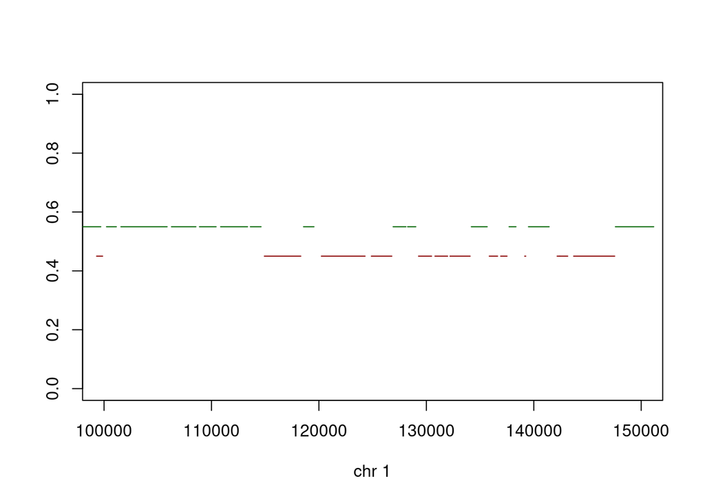

```r
Chrom = 'NC_001133.9'
From = 100000
To   = 150000
plot(c(From, To), c(0, 1), type = 'n', xlab = 'chr 1', ylab = '')
PosGenes <- gtf$seqid == Chrom & gtf$type == 'gene' & gtf$strand == '+'
NegGenes <- gtf$seqid == Chrom & gtf$type == 'gene' & gtf$strand == '-'
segments(gtf[PosGenes, 'start'], 0.45, gtf[PosGenes, 'end'], 0.45, col = 'darkred')
segments(gtf[NegGenes, 'start'], 0.55, gtf[NegGenes, 'end'], 0.55, col = 'darkgreen')
```

- Modifica los límites `From` y `To` para explorar otras regiones de ese o de otro cromosoma.

## Control de calidad de lecturas cortas

El archivo `data/yeast.fastq.gz` contiene las secuencias cortas producidas por la secuenciación de la cepa de interés. Antes de alinear estas secuencias al genoma de referencia, realizamos un análisis de su calidad.

La función `qa()` del paquete `ShortRead` realiza un análisis de la calidad de las lecturas de uno o varios archivos FASTQ. Observa los cambios que se producen en tu carpeta de trabajo cuando ejecutas los comandos siguientes.

```r
suppressMessages(library('ShortRead'))
QC <- qa('data', type = 'fastq', pattern = '*.fastq.gz')
report(QC, dest = 'informe_de_calidad')
```

```
## [1] "informe_de_calidad/index.html"
```

- ¿Qué longitudes tienen las secuencias?
- ¿Cómo varía la calidad de la secuencia a lo largo de su longitud?

## Mapeo de lecturas cortas

El programa `bwa` se ejecuta fuera de R, y podemos invocarlo en un bloque de código de `bash` desde RStudio para alinear las lecturas cortas al genoma de referencia. Primero, el programa necesita generar un *índice* del genoma de referencia. Observa los cambios que se producen en tu carpeta de trabajo al ejecutar los comandos siguientes.

```bash
bwa index data/yeast.fasta
```

```
## [bwa_index] Pack FASTA... 0.01 sec
## [bwa_index] Construct BWT for the packed sequence...
## [bwa_index] 0.23 seconds elapse.
## [bwa_index] Update BWT... 0.01 sec
## [bwa_index] Pack forward-only FASTA... 0.02 sec
## [bwa_index] Construct SA from BWT and Occ... 0.14 sec
## [main] Version: 0.7.17-r1188
## [main] CMD: bwa index data/yeast.fasta
## [main] Real time: 0.766 sec; CPU: 0.404 sec
```

Y después se realiza el alineamiento.

```bash
bwa mem data/yeast.fasta data/yeast.fastq.gz -o yeast.sam
```

```
## [M::bwa_idx_load_from_disk] read 0 ALT contigs
## [M::process] read 59584 sequences (2740864 bp)...
## [M::mem_process_seqs] Processed 59584 reads in 0.537 CPU sec, 0.539 real sec
## [main] Version: 0.7.17-r1188
## [main] CMD: bwa mem -o yeast.sam data/yeast.fasta data/yeast.fastq.gz
## [main] Real time: 0.717 sec; CPU: 0.597 sec
```

El resultado se habrá guardado en el archivo de texto `yeast.sam`. Podemos extraer algunas estadísticas útiles del alineamiento si primero lo convertimos al formato binario `BAM` (`samtools view -b`), después lo ordenamos (`samtools sort`), y por último lo *indexamos* (`samtools index`). Todo ello, desde el terminal de `bash` o en un bloque de código de `bash` en RStudio:

```bash
samtools view -b -o yeast.bam yeast.sam
samtools sort -o sorted.bam yeast.bam
samtools index sorted.bam
```

```bash
mkdir bamstats
samtools stats sorted.bam > bamstats/stats.txt
plot-bamstats -p bamstats/ bamstats/stats.txt
```